# 02.Example 2

# Given:

A long conducting rod of diameter $D$ and electrical resistance per unit length $R'_e$ is initially in thermal equilibrium with the ambient air and its surroundings. This equilibrium is disturbed when an electrical current $I$ is passed through the rod.

[figure not shown]

The various parameters are shown below.  
$D=1 mm$  
$L=1 m$  
$R'_e=0.4 \frac{\Omega}{m}$  
$T_{\infty}=300 K$  
$T_{sur}=300 K$  
$h=100 \frac{W}{m^2 K}$  
$\varepsilon=0.8$

# Required:

Develop an equation that could be used to compute the variation of the rod temperature with current at steady state conditions and fixed environmental conditions. Plot the resulting relationship for current ranging from $0$ to $10 A$.

# Solution:

Start first by importing any needed libraries.

```python
import math
import matplotlib.pyplot as plt
import numpy as np
import pint # https://pint.readthedocs.io
```

The unit registry may then be defined. This is shown below.

```python
ureg=pint.UnitRegistry()
ureg.setup_matplotlib(True)
Q_=ureg.Quantity
```

The given problem variables may now be defined with units.

```python
D=Q_(1, 'mm')
L=Q_(1, 'm')
R_e=Q_(0.4, 'ohm/m')
T_inf=Q_(300, 'K')
T_sur=Q_(300, 'K')
h=Q_(100, 'W/(m^2 K)')
es=0.8
```

Other known quantities that will be used are shown below.

```python
sig=Q_(5.67*10**-8, 'W/(m^2 K^4)')
```

Using the 1st Law of Thermodynamics,  
$\frac{dE_{sys}}{dt} = \Sigma \dot{E}_{in} - \Sigma \dot{E}_{out} $  
Assuming steady state conditions shows  
$0 = \Sigma \dot{E}_{in} - \Sigma \dot{E}_{out}$  
The energy entering the system is due to the heat generated by the current. Thus, $\Sigma E_{in} = I^2 R'_e L$  
Remember that the resistor power is  
$P_R = IV = I \frac{I}{R} = I^2 R$  
For this particular rod, the total resistance is given by  
$R = R'_e L$  
The energy leaving the system is due to the convection and radiation. Thus,  
$\Sigma E_{out} = \dot{Q}_{conv} + \dot{Q}_{rad}$  
THe convection and radiation terms then become  
$\Sigma E_{out} = hA\left( T_s - T_{\infty}\right) + \varepsilon \sigma A \left( T_s^4 - T_{sur}^4\right)$  
Where the $A$ term is the surface area of the rod and is given by  
$A = \pi D L$  
The simplified energy balance is then  
$ 0 = I^2 R'_e L - h \left( \pi D L\right) \left( T_s - T_{\infty}\right) - \varepsilon \sigma \left( \pi D L\right) \left( T_s^4 - T_{sur}^4\right)$  
Inspecting the expression above, it may be seen that everything is known expect the surface temperature $T_s$ (while the current $I$ is not a fixed value it is still a known value). Similar to the previous problem, there is no closed-form solution. The Newton-Raphson method of root finding will be implemented again to reach a solution. The `newton_raphson` function is defined below.

```python
def newton_raphson(f, x, xFixed, tol=0.001):
    h=0.000000001
    while(abs(f(x, xFixed)) > tol):
        df=(f(x+h, xFixed)-f(x, xFixed))/h
        x=x-f(x, xFixed)/df
    return x
```

The heat transfer expression may now be defined as a python function. This is shown below.

```python
def hx_expr(T_s, I):
    I_=I.to_base_units().magnitude
    R_e_=R_e.to_base_units().magnitude
    L_=L.to_base_units().magnitude
    h_=h.to_base_units().magnitude
    D_=D.to_base_units().magnitude
    T_inf_=T_inf.to('K').magnitude
    sig_=sig.to_base_units().magnitude
    T_sur_=T_sur.to('K').magnitude
    return I_**2*R_e_*L_-h_*math.pi*D_*L_*(T_s-T_inf_)-es*sig_*math.pi*D_*L_*(T_s**4-T_sur_**4)
```

The range of the current values may now be defined.

```python
I=np.linspace(0, 10, 50)*ureg.A
```

Now for every current value in the range, the surface temperature may be found. This is shown below.

```python
T_s=[]
for Ie in I:
    T_s.append(newton_raphson(hx_expr, 100, Ie))
T_s=T_s*ureg.K
```

The plot may now be generated. This is shown below.

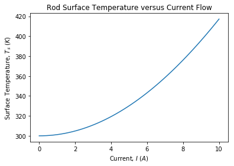

```python
fig, ax=plt.subplots(1, 1)
ax.plot(I, T_s)
ax.set_xlabel('Current, $I\\ \\left(A \\right)$')
ax.set_ylabel('Surface Temperature, $T_s \\ \\left( K \\right)$')
ax.set_title('Rod Surface Temperature versus Current Flow')
plt.show()
```